# Decision Tree

Aaditya Hemant 19BAI1098

```python
import pandas as pd
import numpy as np
import matplotlib.pyplot as plt
import seaborn as sns
```

```python
data= pd.read_csv('./data/car_evaluation.csv')
data.head()
```

|  | vhigh | vhigh.1 | 2 | 2.1 | small | low | unacc |
| --- | --- | --- | --- | --- | --- | --- | --- |
| 0 | vhigh | vhigh | 2 | 2 | small | med | unacc |
| 1 | vhigh | vhigh | 2 | 2 | small | high | unacc |
| 2 | vhigh | vhigh | 2 | 2 | med | low | unacc |
| 3 | vhigh | vhigh | 2 | 2 | med | med | unacc |
| 4 | vhigh | vhigh | 2 | 2 | med | high | unacc |

Class Values:  
unacc, acc, good, vgood  
unacceptable,acceptable,good,very good

Attributes:

buying: Purchase cost vhigh, high, med, low.  
maint: vhigh, high, med, low.  
doors: 2, 3, 4, 5more.  
persons: 2, 4, more.  
lug_boot: small, med, big.  
safety: low, med, high.

Class is the dependent variable

```python
data.columns = ['bp', 'maint', 'doors', 'persons', 'lug_boot', 'safety', 'class']
```

Assign proper column names

```python
data.head()
```

|  | bp | maint | doors | persons | lug_boot | safety | class |
| --- | --- | --- | --- | --- | --- | --- | --- |
| 0 | vhigh | vhigh | 2 | 2 | small | med | unacc |
| 1 | vhigh | vhigh | 2 | 2 | small | high | unacc |
| 2 | vhigh | vhigh | 2 | 2 | med | low | unacc |
| 3 | vhigh | vhigh | 2 | 2 | med | med | unacc |
| 4 | vhigh | vhigh | 2 | 2 | med | high | unacc |

```python
data.info()
```

```
<class 'pandas.core.frame.DataFrame'>
RangeIndex: 1727 entries, 0 to 1726
Data columns (total 7 columns):
 #   Column    Non-Null Count  Dtype
---  ------    --------------  -----
 0   bp        1727 non-null   object
 1   maint     1727 non-null   object
 2   doors     1727 non-null   object
 3   persons   1727 non-null   object
 4   lug_boot  1727 non-null   object
 5   safety    1727 non-null   object
 6   class     1727 non-null   object
dtypes: object(7)
memory usage: 94.6+ KB
```

```python
data.describe()
```

|  | bp | maint | doors | persons | lug_boot | safety | class |
| --- | --- | --- | --- | --- | --- | --- | --- |
| count | 1727 | 1727 | 1727 | 1727 | 1727 | 1727 | 1727 |
| unique | 4 | 4 | 4 | 3 | 3 | 3 | 4 |
| top | med | med | 5more | more | med | med | unacc |
| freq | 432 | 432 | 432 | 576 | 576 | 576 | 1209 |

```python
data['class'].value_counts()
```

```
unacc    1209
acc       384
good       69
vgood      65
Name: class, dtype: int64
```

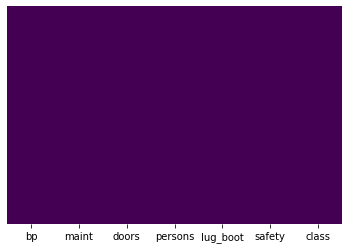

```python
sns.heatmap(data.isnull(),yticklabels=False,cbar = False,cmap='viridis')
```

There is no missing data

```python
data.shape
```

```
(1727, 7)
```

```python
data['doors'].unique()
```

```
array(['2', '3', '4', '5more'], dtype=object)
```

```python
data['persons'].unique()
```

```
array(['2', '4', 'more'], dtype=object)
```

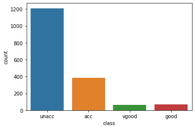

```python
sns.countplot(x='class',data=data)
```

There exists a large discrepancy in the count of the class variable. This data would not be suitable for linear regression models. Therefore we will make use of Decision tree.

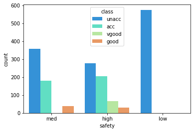

```python
sns.countplot(x='safety',hue='class',data=data,palette='rainbow')
```

We see that vehicles with low safety are always unacceptable. Additionally Only vehicles with high safety can be classified as vgood.

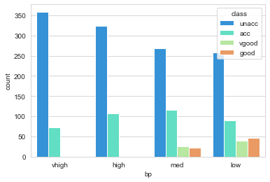

```python
sns.set_style('whitegrid')
sns.countplot(x='bp',hue='class',data=data,palette='rainbow')
```

The lower the buying price(bp) the better class of the vehicle

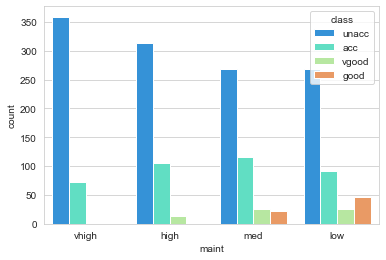

```python
sns.set_style('whitegrid')
sns.countplot(x='maint',hue='class',data=data,palette='rainbow')
```

The lower the maintainence price the better the class of the vehicle.

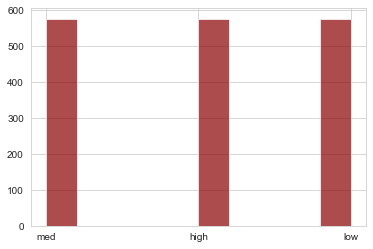

```python
data['safety'].hist(color='darkred',alpha=0.7)
```

There is an even distribution of values for safety

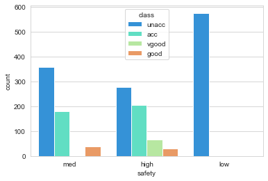

```python
sns.countplot(x='safety',hue='class',data=data,palette='rainbow')
```

Low safety vehicles are classes as low. High safety is required to be classified as vgood.

# Modelling

```python
import category_encoders as ce
```

```python
from sklearn.model_selection import train_test_split
```

```python
X_train, X_test, y_train, y_test = train_test_split(data.drop('class',axis=1),
                                                    data['class'], test_size=0.30,
                                                    random_state=101)
```

```python
encoder = ce.OrdinalEncoder(cols=['bp', 'maint', 'doors', 'persons', 'lug_boot', 'safety'])

X_train = encoder.fit_transform(X_train)
X_test = encoder.transform(X_test)
```

```python
from sklearn.tree import DecisionTreeClassifier
```

```python
dtree = DecisionTreeClassifier()
```

```python
dtree.fit(X_train, y_train)
```

```
DecisionTreeClassifier()
```

```python
predictions = dtree.predict(X_test)
```

```python
from sklearn.metrics import classification_report
from sklearn.metrics import confusion_matrix
```

```python
print(classification_report(y_test,predictions))
```

```
              precision    recall  f1-score   support

         acc       0.93      0.91      0.92       109
        good       0.80      0.94      0.86        17
       unacc       0.98      0.98      0.98       373
       vgood       1.00      0.95      0.97        20

    accuracy                           0.96       519
   macro avg       0.93      0.94      0.93       519
weighted avg       0.96      0.96      0.96       519
```

```python
mat = confusion_matrix(y_test, predictions)
print(mat)
```

```
[[ 99   2   8   0]
 [  1  16   0   0]
 [  6   2 365   0]
 [  1   0   0  19]]
```

Visualization using graphviz

```python
from sklearn import tree
import matplotlib.image as pltimg
```

```python
from IPython.display import Image
from six import StringIO
from sklearn.tree import export_graphviz
import pydotplus

features = list(data.columns[:-1])
features
```

```
['bp', 'maint', 'doors', 'persons', 'lug_boot', 'safety']
```

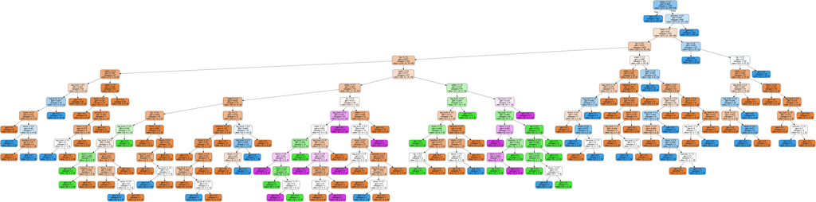

```python
dot_data = StringIO()
export_graphviz(dtree, out_file=dot_data,feature_names=features,filled=True,rounded=True)

graph = pydotplus.graph_from_dot_data(dot_data.getvalue())
Image(graph.create_png())
```

The model has an accuracy of 0.96. We can conclude that the generated decision tree is good.